# Cournot Nash Equilibrium

Industrial Organization and Competition Policy

Marly Tatiana Celis

December 7th, 2023

# Cournot Market Structure

This is a simple code for representing the Cournot equilibrium for a duopoly when market demand is $Q(P)=200-P$. Each firm’s cost function is $C(q_i )=20q_i$, where $i=1,2$.

- In this case the Cournot model corresponds to two firms with symmetric costs.
- Each firm’s goal is to chose the level of output that maximizes profits, given the output of the other firm.
- Firm i’s payoffs are profits $\pi_i(q_i,q_j)=(p-c)q_i$

# Create data frame with output values for each firm

The first step consist on creating a data frame with two columns. On column for the output for firm 1 and another column with the output for firm 2.

Next, we create some value with the parameters of the demand and costs functions.

```r
rm(list=ls())

# Create output q and define the range of values
cournotdata <- data.frame(output_firm1 = seq(0, 180, by = 10),
                 output_firm2 = seq(0, 180, by = 10))

# Create values with parameters of the functions
a <- 200
c <- 20
b <- 1
```

# Nash equilibrium

At the Nash equilibrium, recall that each firm must behave optimally assuming that its rival b ehaves optimally. That is, firm $i$ maximizes profits , believing that firm $j$ maximizes its profits. Another way of saying this is that each firm calculates its best response or reply to the expected best-reply behavior of the other firm

$q_1=\frac{a-c-bq_2}{2b}$

$q_2=\frac{a-c-bq_1}{2b}$

# Compute best responses

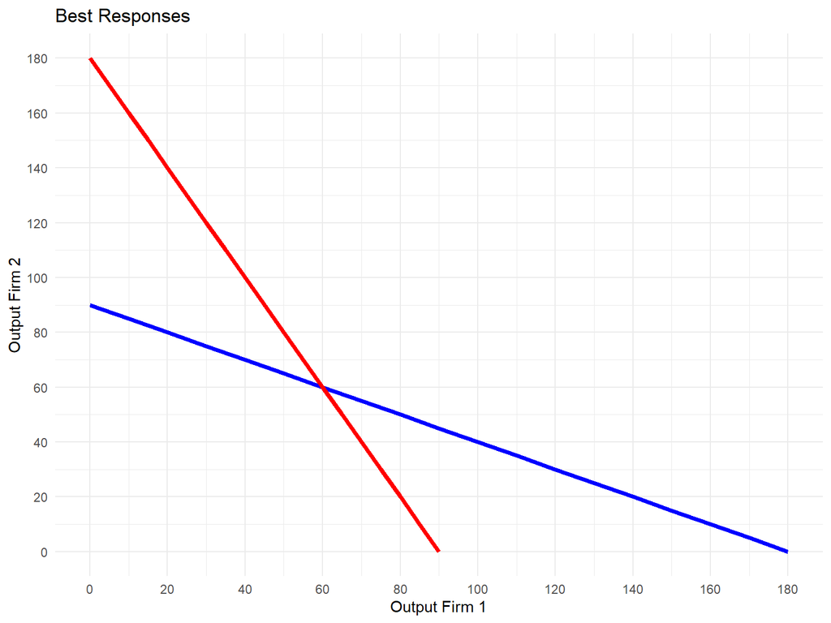

```r
# Compute best responses
cournotdata <- cournotdata %>%
  mutate( bestresp_Firm1 = (a-c-b*output_firm2)*((2*b)^-1),
          bestresp_Firm2 = (a-c-b*output_firm1)*((2*b)^-1)
          )

ggplot() +
  geom_line(data = cournotdata, aes(x = output_firm1, y = bestresp_Firm2), color = "blue", size = 1.5) +
  geom_line(data = cournotdata, aes(x = bestresp_Firm1, y = output_firm2), color = "red", size = 1.5) +
  labs(title = "Best Responses", x = "Output Firm 1", y = "Output Firm 2") +
  scale_x_continuous(breaks = seq(0, max(cournotdata$output_firm1, cournotdata$bestresp_Firm1), by = 20)) +
  scale_y_continuous(breaks = seq(0, max(cournotdata$output_firm1, cournotdata$bestresp_Firm1), by = 20)) +
  theme_minimal()
```

# Compute equilibrium

Solving simultaneaously for $q_1$ and $q_2$ we get

$q_1 =\frac{a-c}{3b}$

$q_2 =\frac{a-c}{3b}$

Compute best responses

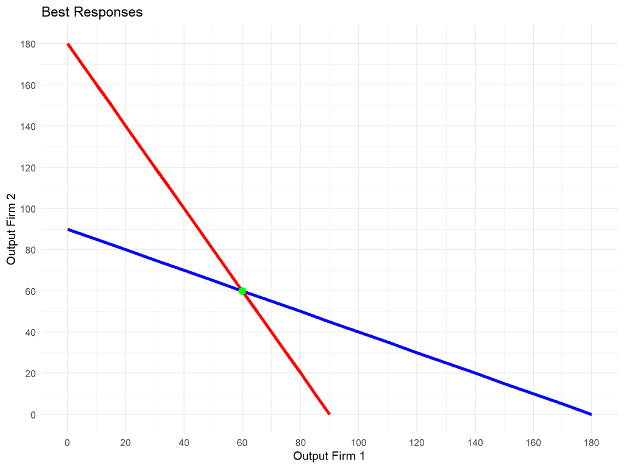

```r
# Compute best responses

nashoutput_firm1= (a-c)*((3*b)^-1)
nashoutput_firm2= (a-c)*((3*b)^-1)

ggplot() +
  geom_line(data = cournotdata, aes(x = output_firm1, y = bestresp_Firm2), color = "blue", size = 1.5) +
  geom_line(data = cournotdata, aes(x = bestresp_Firm1, y = output_firm2), color = "red", size = 1.5) +
  labs(title = "Best Responses", x = "Output Firm 1", y = "Output Firm 2") +
  geom_point(aes(x = nashoutput_firm1, y = nashoutput_firm2), color = "green", size = 3) +  # Add the single point
  scale_x_continuous(breaks = seq(0, max(cournotdata$output_firm1, cournotdata$bestresp_Firm1), by = 20)) +
  scale_y_continuous(breaks = seq(0, max(cournotdata$output_firm1, cournotdata$bestresp_Firm1), by = 20)) +
  theme_minimal()
```